# Assignment 1

Ignacio Lafuente

9/13/2020

# Creative Assignment 1

## Relationships and distributions

### Selected county:

Montgomery County, MD

### Selected variables:

- Rural (dummy)
- Majority ethnicity
- Percentage of renter households
- Average household size
- Total population
- Median age

(observations are census tracts)

```r
library(ggplot2)
library(tidyverse)
library(tidycensus)
library(viridis)
library(ggcorrplot)
```

```r
vars <- c(tot_hh = "H001001",
          tot_rural_hh = "H002005",
          tot_rent_hh = "H004004",
          avg_hh_size = "H012001",
          tot_pop = "P003001",
          nh_white_pop = "P005003",
          nh_black_pop = "P005004",
          nh_asian_pop = "P005006",
          hispanic_pop = "P005010",
          med_age = "P013001")

montg_tracts <- get_decennial(geography = "tract", variables = vars,
                           state = "MD", county = "Montgomery county",
                           output = "wide") %>%
  mutate(rural = (tot_rural_hh == tot_hh) ,
         pct_rental = tot_rent_hh / tot_hh,
         majority_race_eth = case_when(
           nh_white_pop / tot_pop > 0.5 ~ "nh_white",
           nh_black_pop / tot_pop > 0.5 ~ "nh_black",
           nh_asian_pop / tot_pop > 0.5 ~ "nh_asian",
           hispanic_pop / tot_pop > 0.5 ~ "hispanic",
           (nh_white_pop + nh_black_pop + nh_asian_pop + hispanic_pop) /
             tot_pop < 0.5 ~ "other",
           TRUE ~ "None")) %>%
  filter(tot_pop > 0, tot_hh > 0) %>%
  select(GEOID, rural, majority_race_eth,
         pct_rental, avg_hh_size, tot_pop, med_age)
```

```
## Using Census Summary File 1
```

## Plot 1

### Trends for median age and percentage of renters correlation, according to majority ethnicity

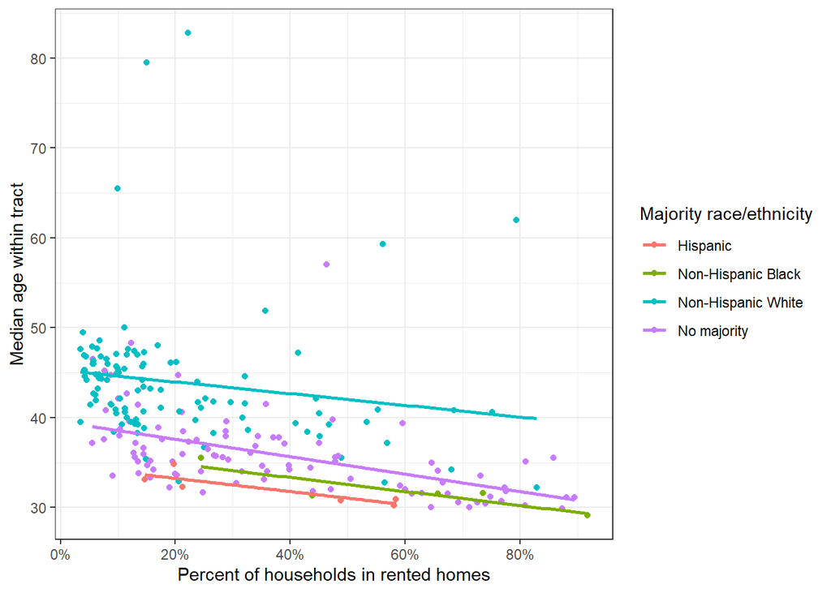

```r
ggplot(montg_tracts,
       aes(x = pct_rental,
           y = med_age,
           color = majority_race_eth)) +
  geom_point() +
  stat_smooth(method = "lm", se = FALSE) +
  scale_x_continuous(name = "Percent of households in rented homes",
                     breaks = seq(0, 1, by = 0.20),
                     labels = paste(seq(0, 100, by = 20), "%", sep = "")) +
  scale_y_continuous(name = "Median age within tract",
                     breaks = seq(10, 80, by = 10)) +
  scale_color_discrete(name = "Majority race/ethnicity",
                       labels = c("Hispanic",
                                  "Non-Hispanic Black",
                                  "Non-Hispanic White",
                                  "No majority")) +
  theme_bw()
```

##### I was interested in these trends (ownership positively correlates with age, but those trends are clearly different for different ethnicities). I removed the SE shading because I think it is confusing when having many categories and linear fits.

## Plot 2

### Average household size by majority ethnicity

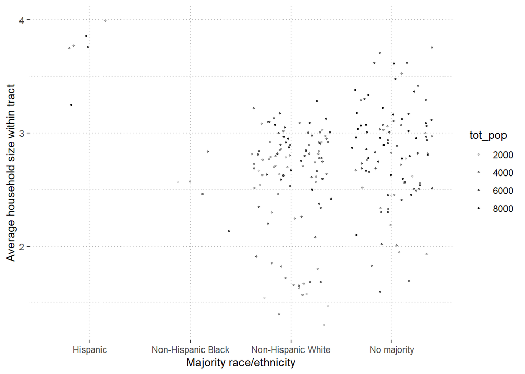

```r
ggplot(montg_tracts,
       aes(x = majority_race_eth,
           y = avg_hh_size,
           alpha = tot_pop)) +
  geom_point(position = "jitter",
             size = 0.5) +
  scale_x_discrete(name = "Majority race/ethnicity",                        labels = c("Hispanic",
                                  "Non-Hispanic Black",
                                  "Non-Hispanic White",
                                  "No majority")) +
  scale_y_continuous(name = "Average household size within tract",
                     breaks = seq(1, 8, by = 1)) +
  theme(panel.background = element_rect(fill = "white"),
        panel.grid = element_line(colour = "gray",
        linetype = "dotted"),
        legend.key = element_rect(fill = "white"))
```

##### I was interested in a social building of the household size, but n is too small for some ethnic majorities. I like this jitter method though, and I was wondering if the way in which the points are horizontally shown is just random (so that they don’t overlap) or if they follow any pattern.

## Plot 3

### Number of tracts of each majority ethnicity

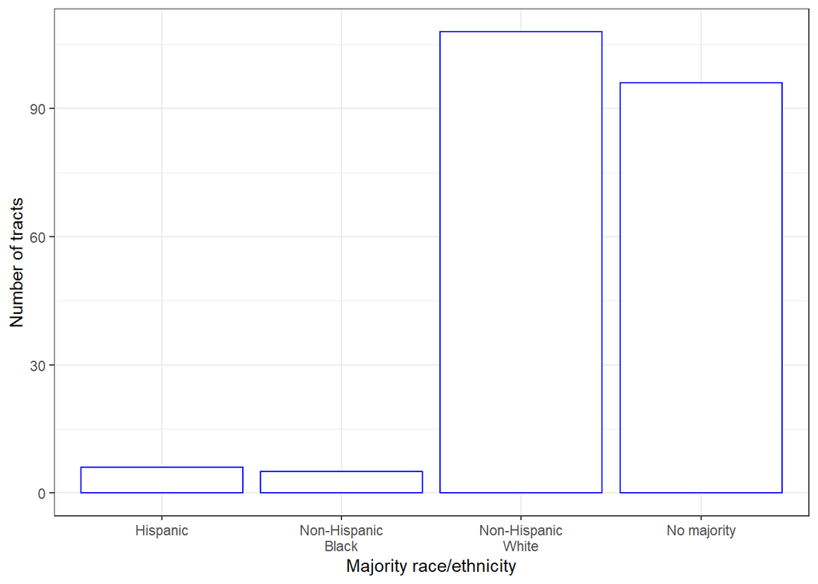

```r
ggplot(montg_tracts, aes(x = majority_race_eth, fill = rural)) +
  geom_bar(color = "blue", fill = "white") +
  scale_y_continuous(name = "Number of tracts") +
  scale_x_discrete(name = "Majority race/ethnicity",
                       labels = c("Hispanic",
                                  "Non-Hispanic\nBlack",
                                  "Non-Hispanic\nWhite",
                                  "No majority")) +
   theme_bw()
```

##### A simple bar chart, trying to avoid default colors.

## Plot 4

### Median age according to urban/rural type of tract

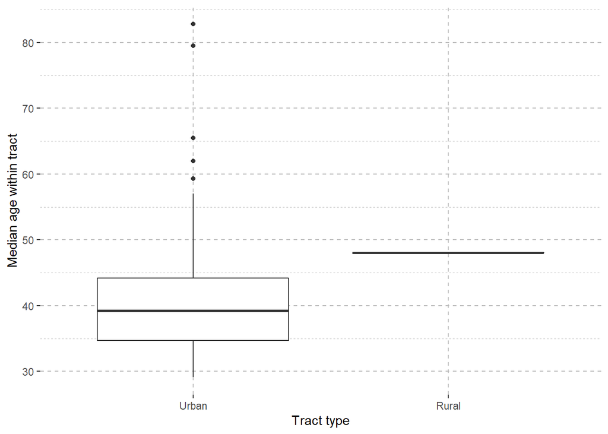

```r
ggplot(montg_tracts,
       aes(x = rural,
           y = med_age)) +
  geom_boxplot() +
  scale_x_discrete(name = "Tract type",
                       labels = c("Urban",
                                  "Rural")) +
  scale_y_continuous(name = "Median age within tract",
                     breaks = seq(10, 80, by = 10)) +
  theme(panel.background = element_rect(fill = "white"),
        panel.grid = element_line(colour = "gray",
        linetype = "dashed")) +
  theme(legend.position = "none")
```

##### An interesting usage of boxplots, comparing urban and rural dwellers. Unfortunately, there was only one rural tract in the sample.

## Plot 5

### Pie chart of tract types

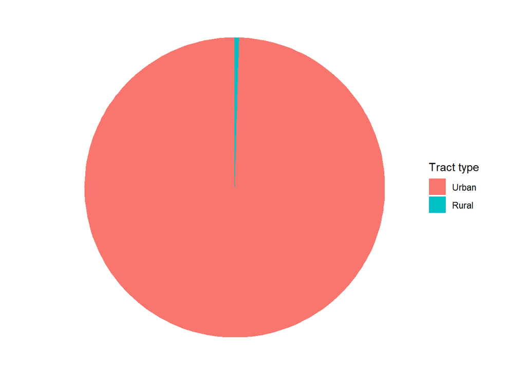

```r
pie_chart <- ggplot(montg_tracts, aes(x = 1, fill = rural)) +
  geom_bar(position = "fill") +
  coord_polar(theta = "y") +
  scale_y_continuous(name = "Number of tracts") +
  scale_fill_discrete(name = "Tract type",
                       labels = c("Urban",
                                  "Rural")) +
  theme_void()

pie_chart
```

##### A default pie chart. I would have liked to explore slices having also a y-dimension (I learned that from Jennifer and explored it through changing x variable) but it would be useful with other variables -not included- maybe.

## Plot 6

### Density of total population for census tracts

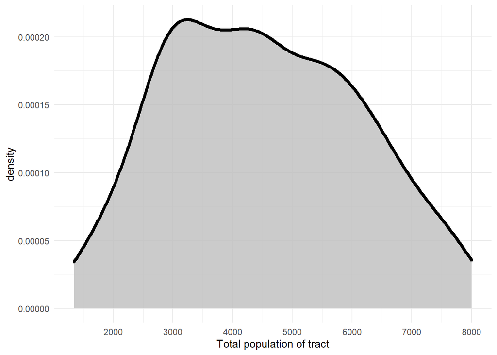

```r
ggplot(montg_tracts, aes(x=tot_pop)) +
  geom_density(fill="gray", color="black", size=1.5, alpha=0.8) +
  scale_x_continuous(name = "Total population of tract",
                     breaks = seq(0, 10000, by = 1000)) +
  theme_minimal()
```

##### A density plot showing how tracts are constituted in terms of population.

## Plot 7

### Median age by majority ethnicity

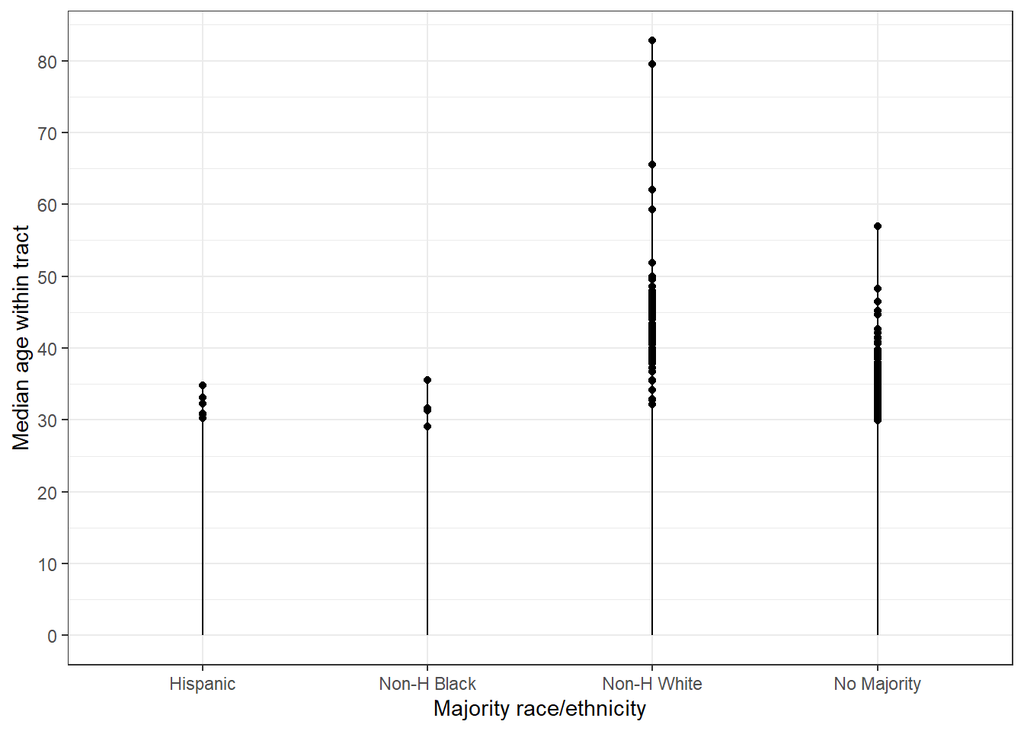

```r
ggplot(montg_tracts, aes(x=majority_race_eth, y=med_age)) +
  geom_point() +
  geom_segment(aes(x=majority_race_eth, xend=majority_race_eth, y=0, yend=med_age)) +
  scale_y_continuous(name = "Median age within tract",
                     breaks = seq(0, 80, by = 10)) +
  scale_x_discrete(name = "Majority race/ethnicity",                       labels = c("Hispanic",
                                  "Non-H Black",
                                  "Non-H White",
                                  "No Majority")) +

theme_bw()
```

##### Again, lower sample size for many ethnicity majorities prevents the plot from being helpful. I like the segments showing range (at least upwards).

## Plot 8

### Quadratic fit for correlation between percentage of renters and total population of tract

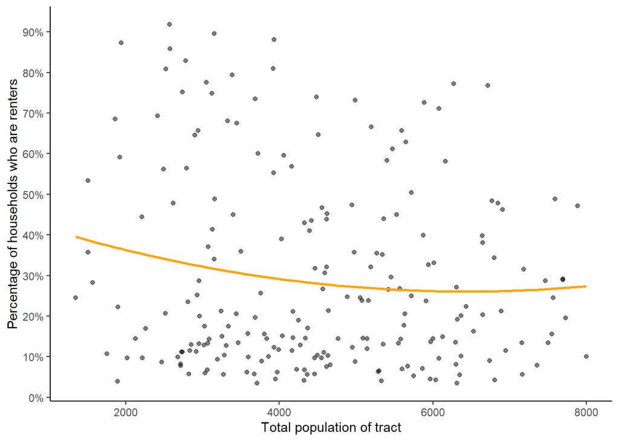

```r
ggplot(montg_tracts, aes(x=tot_pop, y=pct_rental))+
  geom_point(alpha = 0.5) +
  stat_smooth(method = "lm", formula = y ~ poly(x,2), se = FALSE, colour = "orange") +
  scale_y_continuous(name="Percentage of households who are renters",
                     breaks = seq(0, 1, by = 0.1),
                     labels = paste(seq(0, 100, by = 10), "%", sep = "")) +
  scale_x_continuous(name="Total population of tract") +
  theme_classic()
```

##### It isn’t a nice scatterplot, and still another one, but I was experimenting the ‘formula’ term within the possible fits (in this case quadratic, although weakly correlated).

## Plot 9

### Logarithmic fit for correlation between median age and average household size

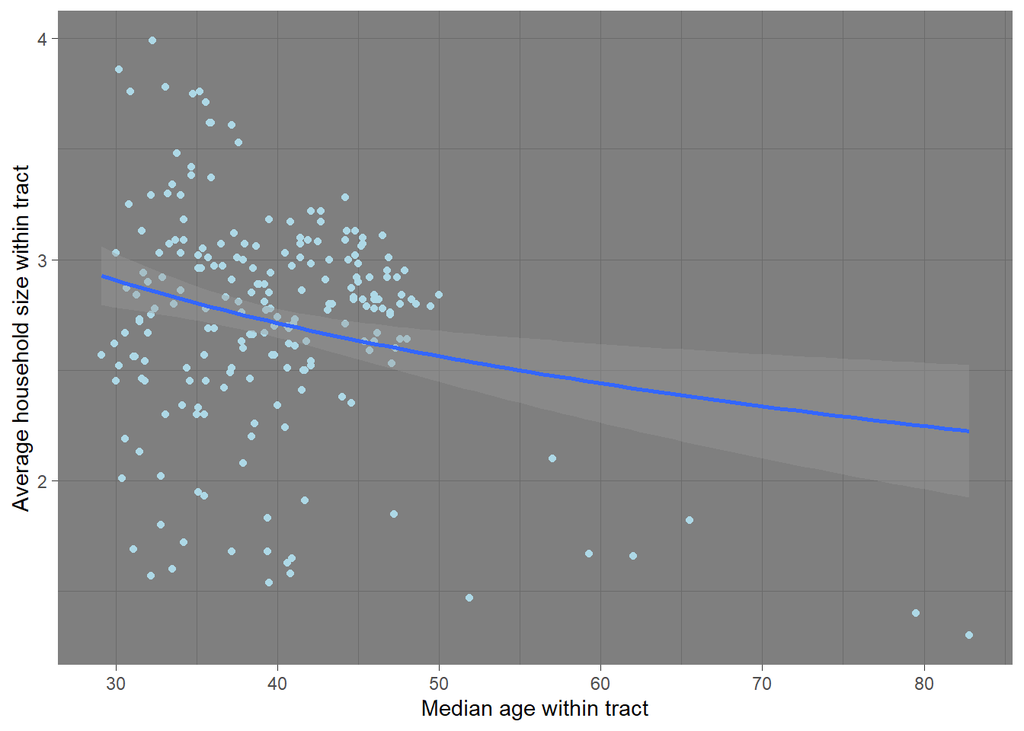

```r
ggplot(montg_tracts,
       aes(x=med_age, y=avg_hh_size)) +
  geom_point(colour = "light blue") +
  stat_smooth(method="lm",formula = y ~ log(x)) +
  scale_y_continuous(name="Average household size within tract") +
  scale_x_continuous(name="Median age within tract")+
  theme_dark()
```

##### I expected a more obvious relationship (bigger households have kids, who should negatively affect the median age within the tract). Maybe if it was average age, the impact would have been higher. In this case, I used a logarithmic fit because I expected it to be more L-shaped, but the middle-left cloud seems to gather most of the points.

## Plot 10

### Correlogram for some continuous variables:

#### Average household size, total population and median age

```r
vars2 <- c(avg_hh_size = "H012001",
          tot_pop = "P003001",
          med_age = "P013001")
montg_tracts2 <- get_decennial(geography = "tract", variables = vars2, state = "MD", county = "Montgomery county", output = "wide") %>%
  filter(tot_pop > 0) %>%
  select(avg_hh_size, tot_pop, med_age)
```

```
## Using Census Summary File 1
```

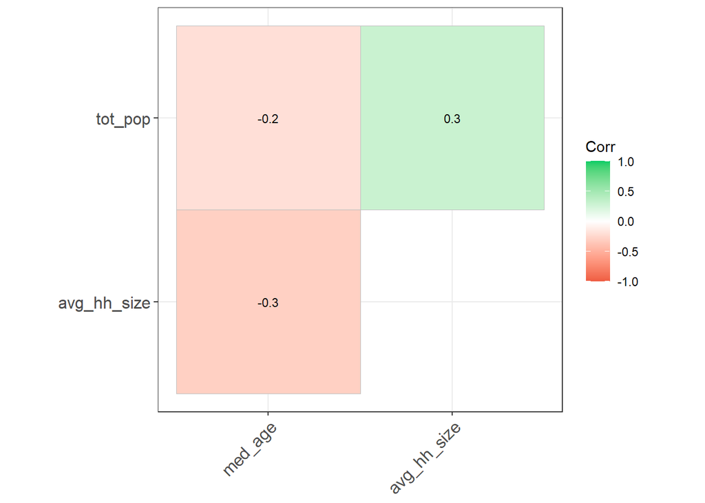

```r
corr <- round(cor(montg_tracts2), 1)
ggcorrplot(corr, hc.order = TRUE,
           type = "upper",
           lab = TRUE,
           lab_size = 3,
           method="square",
           colors = c("tomato2", "white", "springgreen3"),
           ggtheme=theme_bw)
```

##### Some cool stuff I got from a link Marissa provided. I always use this prior to running regressions (so that you can ommit two or more variables that show the same and would thus generate a harmful zero-column in the matrix containing the beta coefficients). The fact is that I had always used it as a formatted table, and a graph looks much better.